# 03 - Fundamentals of data & data visualization

September 5, 2017

## Getting started

## Follow up from last time…

- Any questions on material from last time?
- Any questions on homework?
- Any questions on workflow / course structure?
- Catch up on informal "requirements":
  - Did everyone download the Slack app?
  - Did everyone adjust their Slack username to be/include their (preferred) first name?
  - Did everyone add their photo to the GitHub and Slack profiles?

## R in a nutshell

Functions in R are often verbs, and then in parantheses are the arguments for those functions.

```r
verb(what-you-want-to-apply-verb-to, other-arguments)
```

For example:

```r
glimpse(gapminder)      # Glimpse into the gapminder dataset
```

```r
gapminder %>%           # Pipe into the next function
  filter(year == 1952)  # Filter if year is equal to 1952
```

## Data visualization

## Data visualization

> *"The simple graph has brought more information to the data analyst’s mind than any other device." — John Tukey*
- Data visualization is the creation and study of the visual representation of data.
- There are many tools for visualizing data (R is one of them), and many approaches/systems within R for making data visualizations (**ggplot2** is one of them, and that's the one we're going to use).

## ggplot2

- To use ggplot2 functions, first load the package

```r
library(ggplot2)
```

- In ggplot2 the structure of the code for plots can often be summarized as

```r
ggplot +
  geom_xxx
```

or, more precisely

```r
ggplot(data = [dataset], aes(x = [x-variable], y = [y-variable])) +
   geom_xxx() +
   other options
```

- Geoms, short for geometric objects, describe the type of plot you will produce

## About ggplot2

- ggplot2 is the name of the package
- The `gg` in "ggplot2" stands for Grammar of Graphics
- Inspired by the book **Grammar of Graphics** by Lee Wilkinson
- `ggplot()` is the main function in ggplot2

## Visualizing Star Wars

## Star Wars data

The **dplyr** package contains a dataset called `starwars`:

```r
library(dplyr)
starwars
```

```
## # A tibble: 87 x 13
##                  name height  mass    hair_color  skin_color eye_color
##                 <chr>  <int> <dbl>         <chr>       <chr>     <chr>
##  1     Luke Skywalker    172    77         blond        fair      blue
##  2              C-3PO    167    75          <NA>        gold    yellow
##  3              R2-D2     96    32          <NA> white, blue       red
##  4        Darth Vader    202   136          none       white    yellow
##  5        Leia Organa    150    49         brown       light     brown
##  6          Owen Lars    178   120   brown, grey       light      blue
##  7 Beru Whitesun lars    165    75         brown       light      blue
##  8              R5-D4     97    32          <NA>  white, red       red
##  9  Biggs Darklighter    183    84         black       light     brown
## 10     Obi-Wan Kenobi    182    77 auburn, white        fair blue-gray
## # ... with 77 more rows, and 7 more variables: birth_year <dbl>,
## #   gender <chr>, homeworld <chr>, species <chr>, films <list>,
## #   vehicles <list>, starships <list>
```

## Dataset terminology

What does each row represent? What does each column represent?

```r
starwars
```

```
## # A tibble: 87 x 13
##                  name height  mass    hair_color  skin_color eye_color
##                 <chr>  <int> <dbl>         <chr>       <chr>     <chr>
##  1     Luke Skywalker    172    77         blond        fair      blue
##  2              C-3PO    167    75          <NA>        gold    yellow
##  3              R2-D2     96    32          <NA> white, blue       red
##  4        Darth Vader    202   136          none       white    yellow
##  5        Leia Organa    150    49         brown       light     brown
##  6          Owen Lars    178   120   brown, grey       light      blue
##  7 Beru Whitesun lars    165    75         brown       light      blue
##  8              R5-D4     97    32          <NA>  white, red       red
##  9  Biggs Darklighter    183    84         black       light     brown
## 10     Obi-Wan Kenobi    182    77 auburn, white        fair blue-gray
## # ... with 77 more rows, and 7 more variables: birth_year <dbl>,
## #   gender <chr>, homeworld <chr>, species <chr>, films <list>,
## #   vehicles <list>, starships <list>
```

## Luke Skywalker

[figure not shown]

luke-skywalker

## What's in the Star Wars data?

Take a `glimpse` at the data:

```r
glimpse(starwars)
```

```
## Observations: 87
## Variables: 13
## $ name       <chr> "Luke Skywalker", "C-3PO", "R2-D2", "Darth Vader", ...
## $ height     <int> 172, 167, 96, 202, 150, 178, 165, 97, 183, 182, 188...
## $ mass       <dbl> 77.0, 75.0, 32.0, 136.0, 49.0, 120.0, 75.0, 32.0, 8...
## $ hair_color <chr> "blond", NA, NA, "none", "brown", "brown, grey", "b...
## $ skin_color <chr> "fair", "gold", "white, blue", "white", "light", "l...
## $ eye_color  <chr> "blue", "yellow", "red", "yellow", "brown", "blue",...
## $ birth_year <dbl> 19.0, 112.0, 33.0, 41.9, 19.0, 52.0, 47.0, NA, 24.0...
## $ gender     <chr> "male", NA, NA, "male", "female", "male", "female",...
## $ homeworld  <chr> "Tatooine", "Tatooine", "Naboo", "Tatooine", "Alder...
## $ species    <chr> "Human", "Droid", "Droid", "Human", "Human", "Human...
## $ films      <list> [<"Revenge of the Sith", "Return of the Jedi", "Th...
## $ vehicles   <list> [<"Snowspeeder", "Imperial Speeder Bike">, <>, <>,...
## $ starships  <list> [<"X-wing", "Imperial shuttle">, <>, <>, "TIE Adva...
```

## What's in the Star Wars data?

Run the following **in the Console** to view the help

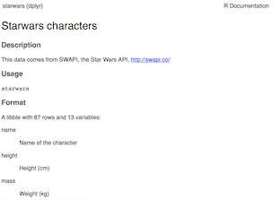

```r
?starwars
```

How many rows and columns does this dataset have? What does each row represent? What does each column represent?

Make a prediction: What relationship do you expect to see between height and mass?

## Scatterplots

## Mass vs. height (`geom_point()`)

```r
ggplot(data = starwars, aes(x = height, y = mass)) +
  geom_point()
```

[output not shown]

- Not all characters have height and mass information (hence 28 of them not plotted)

## Mass vs. height

How would you describe this relationship? What other variables would help us understand data points that don't follow the overall trend?

## Mass vs. height

Who is the not so tall but really chubby character?

[figure not shown]

## Additional variables

Can display additional variables with

- aesthetics (like shape, colour, size), or
- faceting (small multiples displaying different subsets)

## Aesthetics

## Aesthetics options

Visual characteristics of plotting characters that can be **mapped to data** are

- `color`
- `size`
- `shape`
- `alpha` (transparency)

## Mass vs. height + gender

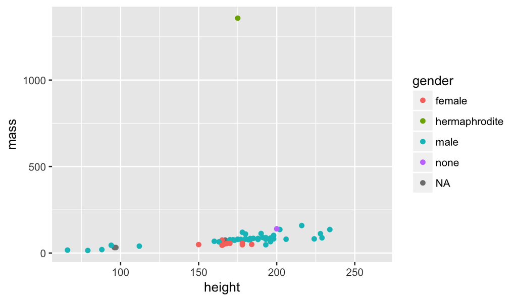

```r
ggplot(data = starwars, aes(x = height, y = mass, color = gender)) +
  geom_point()
```

## Aesthetics summary

- Continuous variable are measured on a continuous scale
- Discrete variables are measured (or often counted) on a discrete scale

| aesthetics | discrete | continuous |
| --- | --- | --- |
| color | rainbow of colors | gradient |
| size | discrete steps | linear mapping between radius and value |
| shape | different shape for each | shouldn't (and doesn't) work |

## Faceting

## Faceting options

- Smaller plots that display different subsets of the data
- Useful for exploring conditional relationships and large data

## Mass vs. height by gender

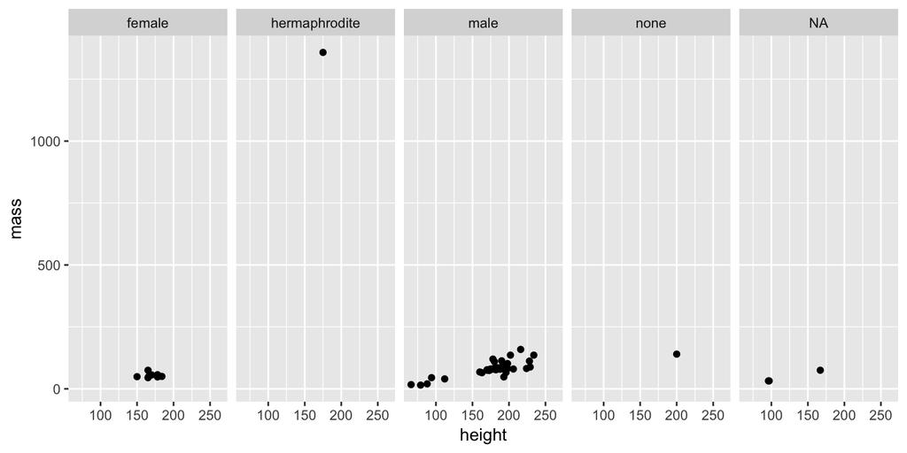

```r
ggplot(data = starwars, aes(x = height, y = mass)) +
  facet_grid(. ~ gender) +
  geom_point()
```

## Dive further…

In the next few slides describe what each plot displays. Think about how the code relates to the output.

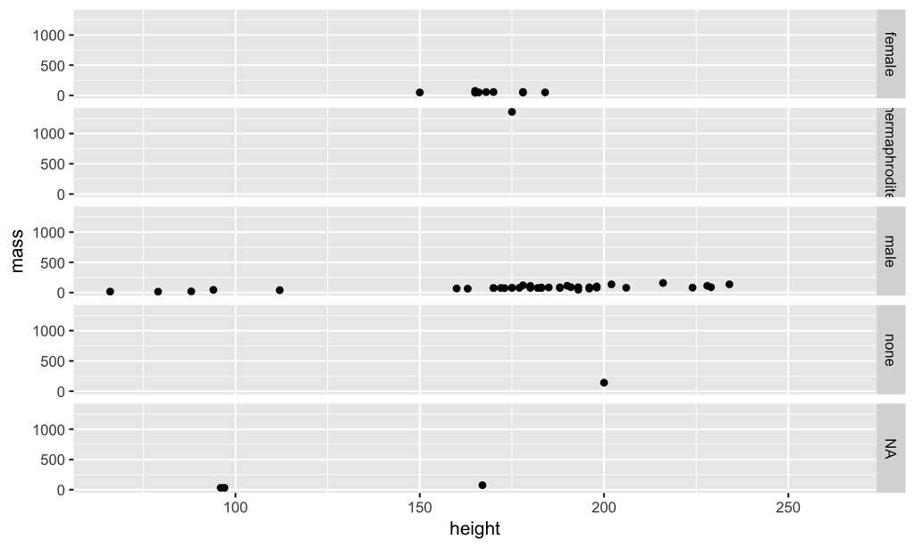

```r
ggplot(data = starwars, aes(x = height, y = mass)) +
  facet_grid(gender ~ .) +
  geom_point()
```

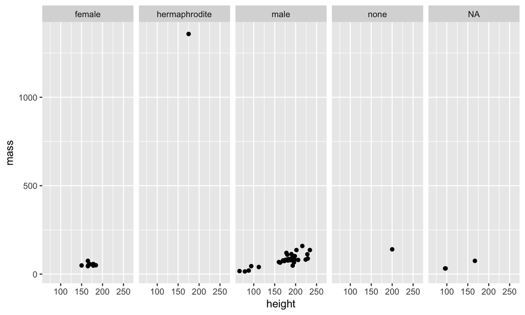

```r
ggplot(data = starwars, aes(x = height, y = mass)) +
  facet_grid(. ~ gender) +
  geom_point()
```

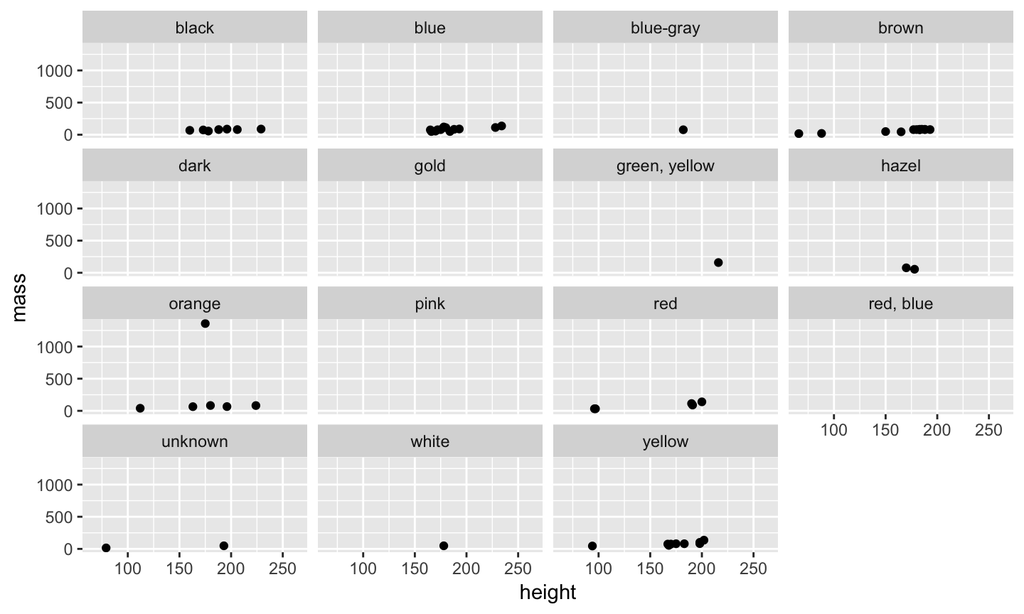

```r
ggplot(data = starwars, aes(x = height, y = mass)) +
  facet_wrap(~ eye_color) +
  geom_point()
```

## Facet summary

- `facet_grid()`: 2d grid, rows ~ cols, . for no split
- `facet_wrap()`: 1d ribbon wrapped into 2d

## Other geoms

## /Height vs. mass, take 2

How are these plots similar? How are they different?

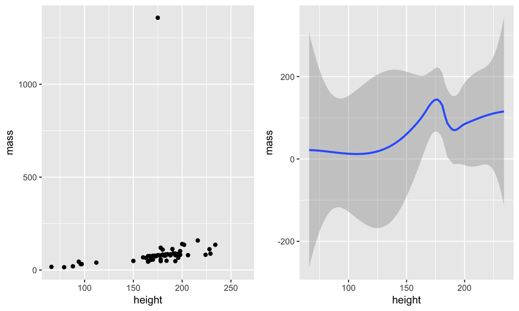

## `geom_smooth`

To plot a smooth curve, use `geom_smooth()`

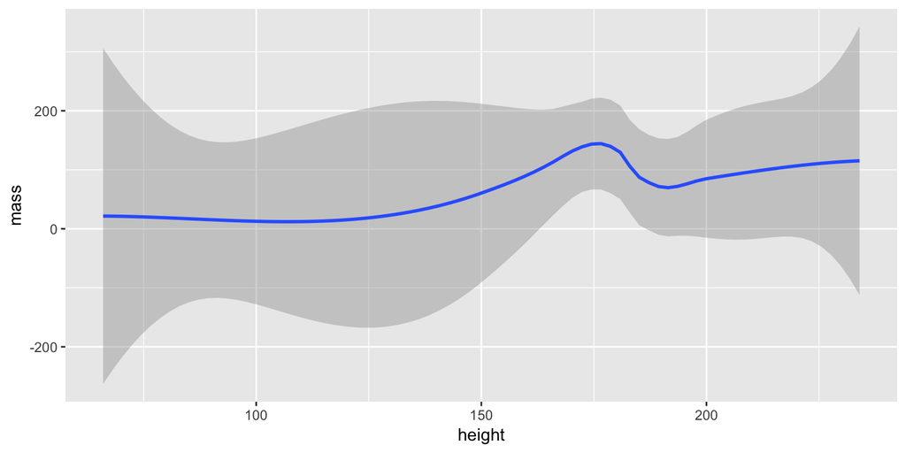

```r
ggplot(data = starwars, aes(x = height, y = mass)) +
  geom_smooth()
```

## Exploratory data analysis (EDA)

## Number of variables involved

- Univariate data analysis - distribution of single variable
- Bivariate data analysis - relationship between two variables
- Multivariate data analysis - relationship between many variables at once, usually focusing on the relationship between two while conditioning for others

## Types of variables

- **Numerical variables** can be classified as **continuous** or **discrete** based on whether or not the variable can take on an infinite number of values or only non-negative whole numbers, respectively.
- If the variable is **categorical**, we can determine if it is **ordinal** based on whether or not the levels have a natural ordering.

## Describing shapes of numerical distributions

- shape:
  - skewness: right-skewed, left-skewed, symmetric (skew is to the side of the longer tail)
  - modality: unimodal, bimodal, multimodal, uniform
- center: mean (`mean`), median (`median`), mode (not always useful)
- spead: range (`range`), standard deviation (`sd`), inter-quartile range (`IQR`)
- unusal observations

## Histograms

For numerical variables

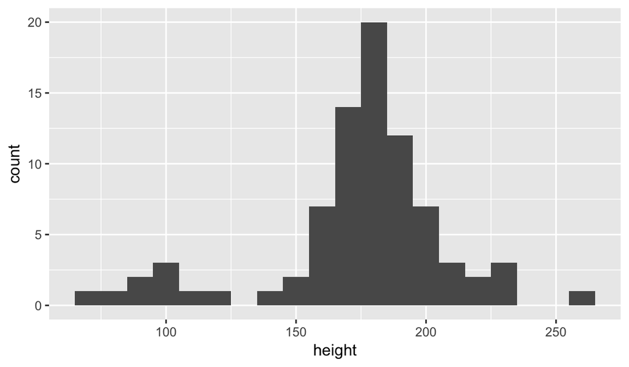

```r
ggplot(starwars, aes(x = height)) +
  geom_histogram(binwidth = 10)
```

## Bar plots

For categorical variables

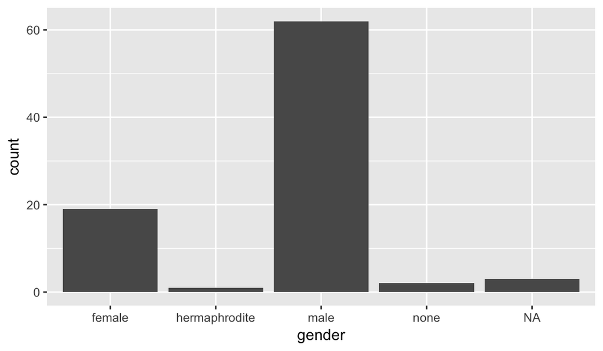

```r
ggplot(starwars, aes(x = gender)) +
  geom_bar()
```